# task04_script

Abby

January 27, 2017

# Task 04 Geol 590

# ggplot2 script

Load proper packages

```r
library(ggplot2)
library(tidyverse)
library(extrafont)
```

determine how many rows the diamonds data set has that comes with ggplot2

```r
nrow(diamonds)
```

```
## [1] 53940
```

There are 53940 rows in diamonds

Use the following code to create a reproducible subset of diamonds. Explain each line of the code in words.

```r
set.seed(1410)
dsmall <- diamonds[sample(nrow(diamonds), 100), ]
```

set.seed(1410) sets the random number generator to start at 1410, if we had started at 10 it would start at 10. dsmall <- diamonds[sample(nrow(diamonds), 100), ] selects 100 random rows from the data table diamonds and returns a new smaller data frame.

### create scatter plots using gglot

Use dsmall to create the following plots: A scatterplot of y vs x, colored by z values and faceted by cut

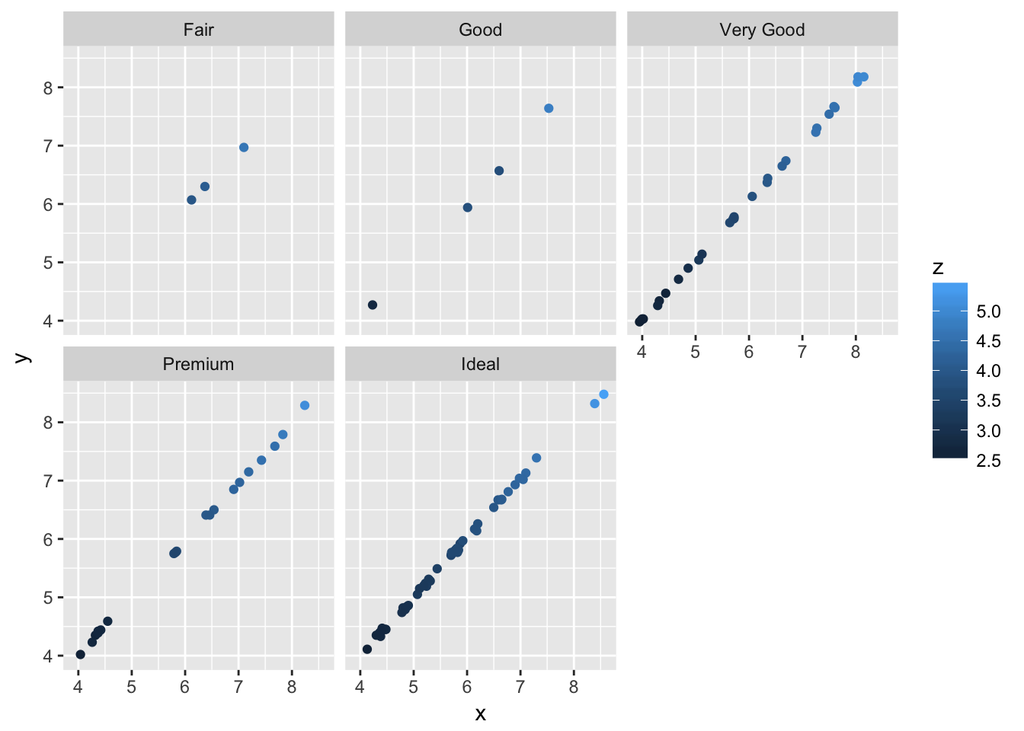

```r
dsmallplot <- ggplot(dsmall,aes( x = x, y = y , colour = z))+
  geom_point()+
  facet_wrap(~cut)
print(dsmallplot)
```

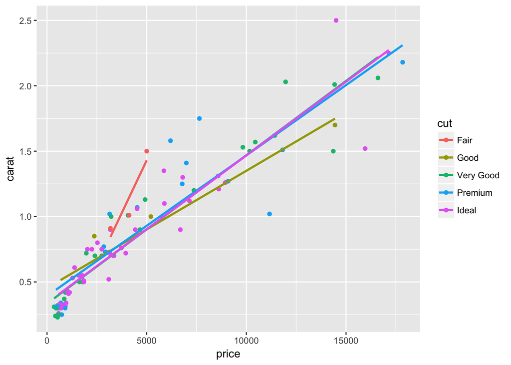

```r
pricecarat <- ggplot(dsmall, aes( x = price, y = carat, color = cut))+
  geom_point()+
  geom_smooth( method = "lm", se = FALSE)
print(pricecarat)
```

A density plot of carat, faceted and colored by clarity

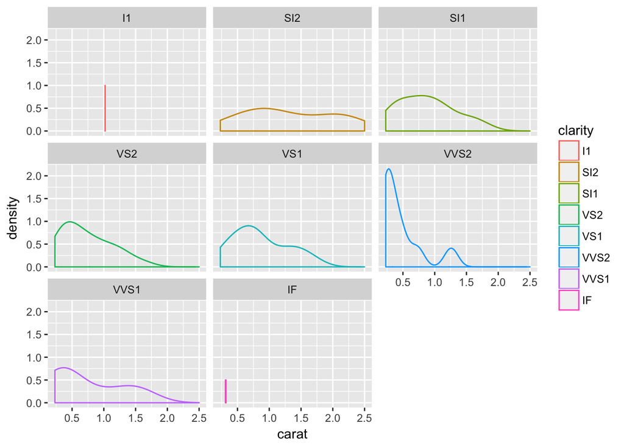

```r
densityplot <-ggplot(dsmall, aes(carat, color = clarity))+
  geom_density()+
  facet_wrap(~clarity)
print(densityplot)
```

A boxplot of price as a function of cut

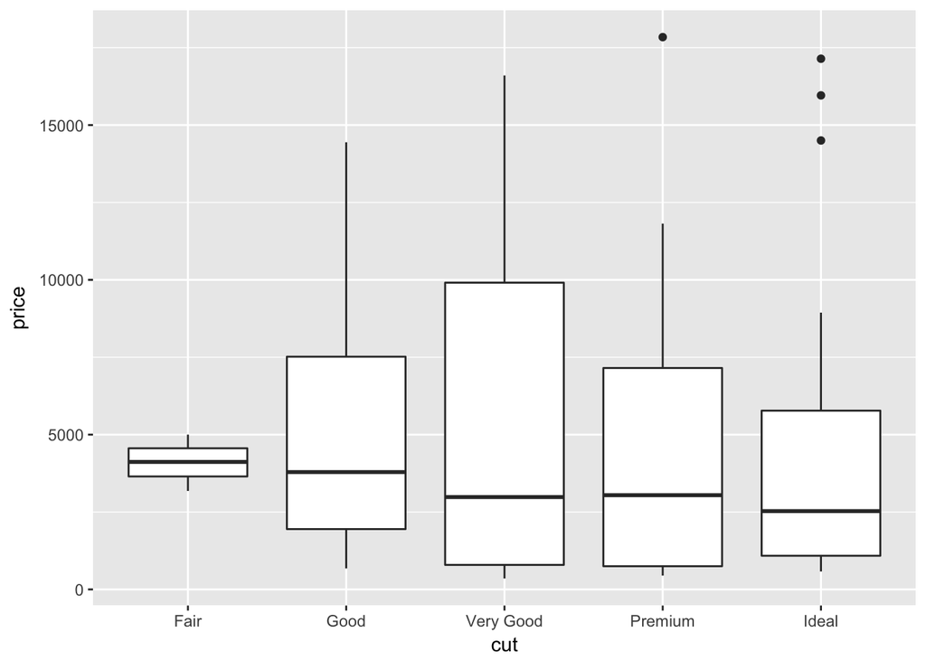

```r
box <- ggplot(dsmall, aes( x = cut, y = price))+
  geom_boxplot()
print(box)
```

A scatterplot of y versus x. The points should be red (colour = “red”), the color of the smoothing line should be blue (colour = “blue”), and the line should be dashed with fat dashes (linetype=2). The x and y labels should be set manually as well. The trickiest part of this may be to figure out where colour = “red” etc should go in the code. Think about mapped vs static aesthetic values.

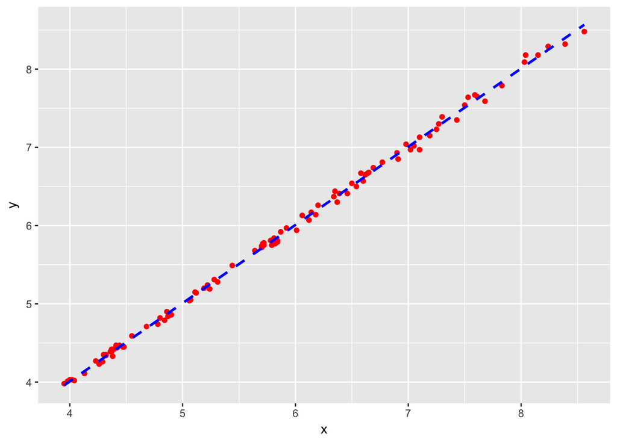

```r
xycolor <- ggplot(dsmall, aes(x = x, y = y))+
  geom_point(color = "red")+
  geom_smooth(method = "lm", se = FALSE, color = "blue", linetype =2)
print(xycolor)
```

[figure not shown]

```r
set.seed(1410)
datasmall <- diamonds[sample(nrow(diamonds), 2500), ]

uglyplot<-ggplot(datasmall, aes(x = carat, y = price, color= clarity, label = color, shape = cut))+
  geom_point( size =1)+
  geom_text(aes(label = ifelse(carat<1.2, as.character(color), '')), hjust=0, vjust=0)+
  ggtitle("[Price per Carat]")+
  xlab("carat")+
  ylab("price")+
  theme(text=element_text(size=25, family="Blanche de la Fontaine"), panel.background =element_rect("darkolivegreen"))+
  scale_colour_brewer(palette = "Set1")
print(uglyplot)
```